# ML_2_Summary

### Comprehensive Example, Regression:

Fit the Tree:

We fit a regression tree to the Boston Housing Data, which is available through the MASS package in R studio and include 14 variables and 506 observations. First, we split data half and half into training and test sets , then fit the regression tree model on the training data only.

```r
library(tree)
library(MASS)
set.seed(1)
train = sample(1:nrow(Boston), nrow(Boston)/2)
tree.boston = tree(medv~., Boston, subset = train)
summary(tree.boston)
```

```
##
## Regression tree:
## tree(formula = medv ~ ., data = Boston, subset = train)
## Variables actually used in tree construction:
## [1] "rm"    "lstat" "crim"  "age"
## Number of terminal nodes:  7
## Residual mean deviance:  10.38 = 2555 / 246
## Distribution of residuals:
##     Min.  1st Qu.   Median     Mean  3rd Qu.     Max.
## -10.1800  -1.7770  -0.1775   0.0000   1.9230  16.5800
```

Plot Tree:

Notice that although the tree grown to full depth has 7 leaves, only four of the variables (rm, lstat, crim and age) have been used to construct this tree. In the context of a regression tree, the deviance is simply the sum of squared errors for the tree. Now, we plot the tree.

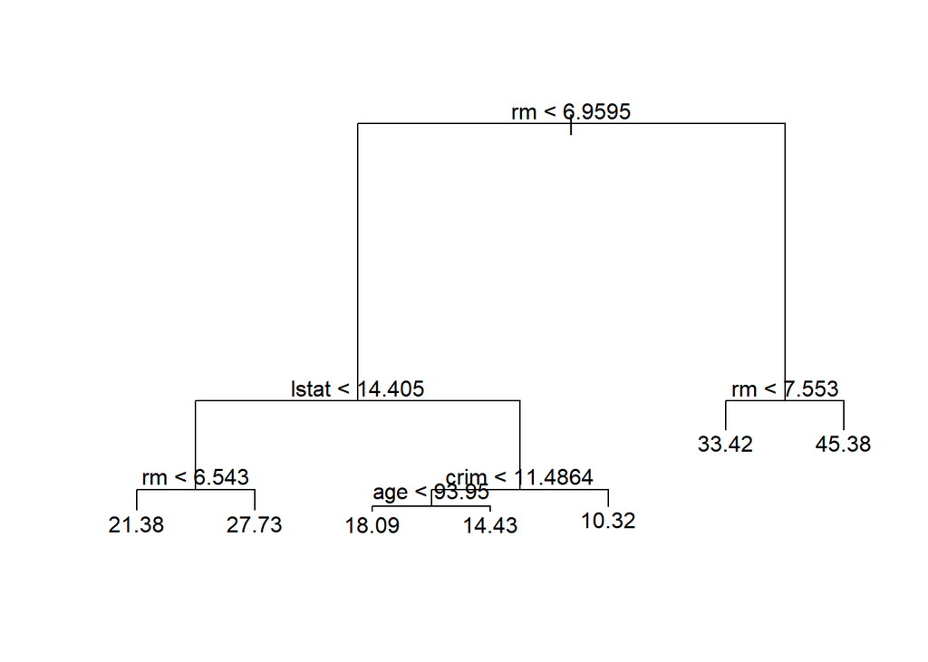

```r
plot(tree.boston)
text(tree.boston,pretty=0)
```

The rm variable measures the average number of rooms per dwelling, and the lstat variable measures the percentage of individuals with lower socioeconomic status. The tree shows that higher values of rm correspond to higher house values and lower values of rm correspond to cheap houses.

Preform Cross-Validation:

Now we use 10-fold cross validation by using cv.tree() function in order to determine the optimal level of tree complexity. This will help us decide whether pruning the tree will improve performance.

```r
cv.boston=cv.tree(tree.boston)
cv.boston
```

```
## $size
## [1] 7 6 5 4 3 2 1
##
## $dev
## [1]  4380.849  4544.815  5601.055  6171.917  6919.608 10419.472 19630.870
##
## $k
## [1]       -Inf   203.9641   637.2707   796.1207  1106.4931  3424.7810 10724.5951
##
## $method
## [1] "deviance"
##
## attr(,"class")
## [1] "prune"         "tree.sequence"
```

Plot the Cross-Validation:

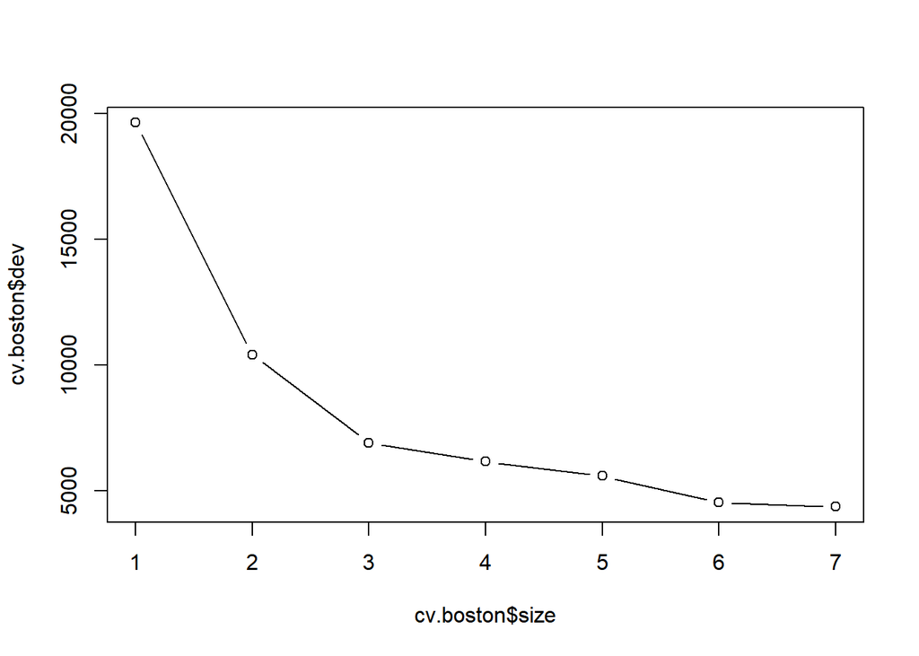

```r
plot(cv.boston$size,cv.boston$dev,type='b')
```

Through the plot, we can find that the most complex tree is selected by cross-validation. However if we wanted to prune the tree, we would use the prune.tree() function as the following.

Make model by using Best Pruned Tree:

```r
prune.boston=prune.tree(tree.boston,best=5)
summary(prune.boston)
```

```
##
## Regression tree:
## snip.tree(tree = tree.boston, nodes = 5L)
## Variables actually used in tree construction:
## [1] "rm"    "lstat"
## Number of terminal nodes:  5
## Residual mean deviance:  13.69 = 3396 / 248
## Distribution of residuals:
##     Min.  1st Qu.   Median     Mean  3rd Qu.     Max.
## -10.1800  -1.9770  -0.1775   0.0000   2.4230  16.5800
```

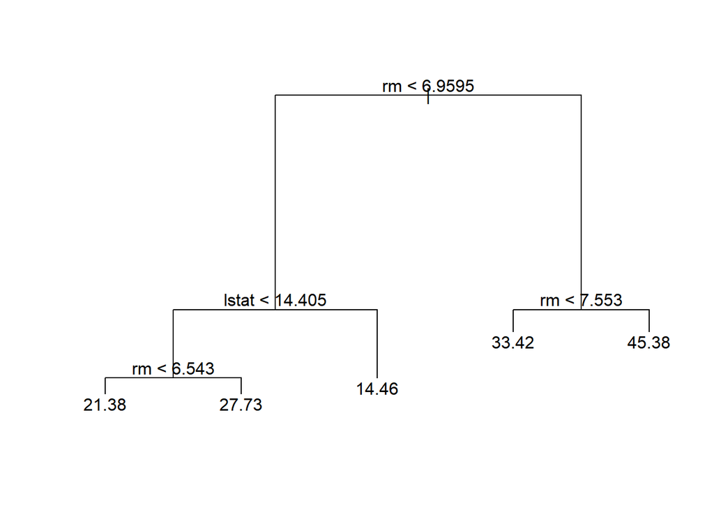

```r
plot(prune.boston)
text(prune.boston,pretty=0)
```

Find the Test Error Rate:

We use the unpruned tree to make predictions on the test set to keep the cross-validation results.

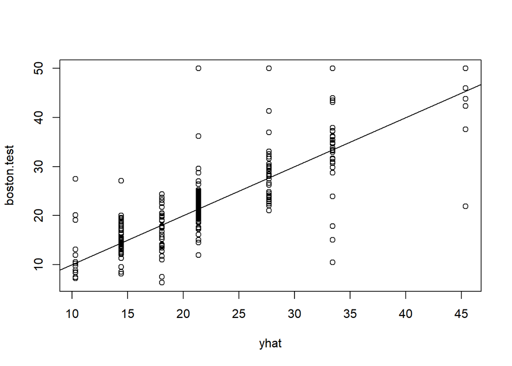

```r
yhat = predict(tree.boston,newdata=Boston[-train,])
boston.test = Boston[-train,"medv"]
plot(yhat, boston.test)
abline(0,1)
```

```r
mean((yhat-boston.test)^2)
```

```
## [1] 35.28688
```

```r
sqrt(mean((yhat-boston.test)^2))
```

```
## [1] 5.940276
```

We got the result that the test set MSE for the regression tree is 35.29, and the square root is around 5.940 which means that this model gives predictions that are within around $5,940 of the true median home value.

### Comprehensive Example, Classification:

Load the Data:

The OJ data contains 1070 purchases where the customer either purchased Citrus Hill or Minute Maid Orange Juice. There are 17 characteristics of the customer and product recorded in the data. The data set is already cleaned as shown in the ‘str’ function, so no data cleaning is required.

```r
library(ISLR)
data(OJ)
str(OJ)
```

```
## 'data.frame':    1070 obs. of  18 variables:
##  $ Purchase      : Factor w/ 2 levels "CH","MM": 1 1 1 2 1 1 1 1 1 1 ...
##  $ WeekofPurchase: num  237 239 245 227 228 230 232 234 235 238 ...
##  $ StoreID       : num  1 1 1 1 7 7 7 7 7 7 ...
##  $ PriceCH       : num  1.75 1.75 1.86 1.69 1.69 1.69 1.69 1.75 1.75 1.75 ...
##  $ PriceMM       : num  1.99 1.99 2.09 1.69 1.69 1.99 1.99 1.99 1.99 1.99 ...
##  $ DiscCH        : num  0 0 0.17 0 0 0 0 0 0 0 ...
##  $ DiscMM        : num  0 0.3 0 0 0 0 0.4 0.4 0.4 0.4 ...
##  $ SpecialCH     : num  0 0 0 0 0 0 1 1 0 0 ...
##  $ SpecialMM     : num  0 1 0 0 0 1 1 0 0 0 ...
##  $ LoyalCH       : num  0.5 0.6 0.68 0.4 0.957 ...
##  $ SalePriceMM   : num  1.99 1.69 2.09 1.69 1.69 1.99 1.59 1.59 1.59 1.59 ...
##  $ SalePriceCH   : num  1.75 1.75 1.69 1.69 1.69 1.69 1.69 1.75 1.75 1.75 ...
##  $ PriceDiff     : num  0.24 -0.06 0.4 0 0 0.3 -0.1 -0.16 -0.16 -0.16 ...
##  $ Store7        : Factor w/ 2 levels "No","Yes": 1 1 1 1 2 2 2 2 2 2 ...
##  $ PctDiscMM     : num  0 0.151 0 0 0 ...
##  $ PctDiscCH     : num  0 0 0.0914 0 0 ...
##  $ ListPriceDiff : num  0.24 0.24 0.23 0 0 0.3 0.3 0.24 0.24 0.24 ...
##  $ STORE         : num  1 1 1 1 0 0 0 0 0 0 ...
```

Split the Data:

Instead of using the book’s method, the data is split using the caret package. The training data contains 80% of the data while the remaining 20% is saved for testing.

```r
library(caret)
set.seed(420)
d_divide<-createDataPartition(OJ$Purchase,p=.8,list = FALSE)
train<-OJ[d_divide,]
test<-OJ[-d_divide,]
```

Fit the Model:

To fit the tree classification model, use the tree library. As seen in the model summary, there are 10 terminal nodes and a training error rate of 15.87%.

```r
library(tree)
model<-tree(Purchase~.,data=train)
summary(model)
```

```
##
## Classification tree:
## tree(formula = Purchase ~ ., data = train)
## Variables actually used in tree construction:
## [1] "LoyalCH"     "SalePriceMM" "PriceDiff"
## Number of terminal nodes:  10
## Residual mean deviance:  0.7509 = 636 / 847
## Misclassification error rate: 0.1587 = 136 / 857
```

Display Detailed Results:

Printing the model shows the break down of each node in the tree. In order it displays the split criterion, the number of observations in that branch, the deviance, the overall prediction for the branch, and the fraction of observations that take on the prediction. It also denotes if a node is a terminal node or not.

```r
model
```

```
## node), split, n, deviance, yval, (yprob)
##       * denotes terminal node
##
##  1) root 857 1146.00 CH ( 0.61027 0.38973 )
##    2) LoyalCH < 0.48285 331  377.10 MM ( 0.25680 0.74320 )
##      4) LoyalCH < 0.0356415 65    0.00 MM ( 0.00000 1.00000 ) *
##      5) LoyalCH > 0.0356415 266  333.30 MM ( 0.31955 0.68045 )
##       10) SalePriceMM < 2.04 144  144.70 MM ( 0.20139 0.79861 ) *
##       11) SalePriceMM > 2.04 122  168.30 MM ( 0.45902 0.54098 )
##         22) LoyalCH < 0.277977 54   63.81 MM ( 0.27778 0.72222 ) *
##         23) LoyalCH > 0.277977 68   91.36 CH ( 0.60294 0.39706 ) *
##    3) LoyalCH > 0.48285 526  475.10 CH ( 0.83270 0.16730 )
##      6) LoyalCH < 0.705326 214  267.60 CH ( 0.68224 0.31776 )
##       12) PriceDiff < -0.165 30   30.02 MM ( 0.20000 0.80000 ) *
##       13) PriceDiff > -0.165 184  202.40 CH ( 0.76087 0.23913 )
##         26) SalePriceMM < 2.125 115  145.90 CH ( 0.66957 0.33043 )
##           52) LoyalCH < 0.6864 110  134.40 CH ( 0.70000 0.30000 ) *
##           53) LoyalCH > 0.6864 5    0.00 MM ( 0.00000 1.00000 ) *
##         27) SalePriceMM > 2.125 69   40.77 CH ( 0.91304 0.08696 ) *
##      7) LoyalCH > 0.705326 312  148.60 CH ( 0.93590 0.06410 )
##       14) PriceDiff < -0.39 13   17.94 CH ( 0.53846 0.46154 ) *
##       15) PriceDiff > -0.39 299  113.10 CH ( 0.95318 0.04682 ) *
```

Plot the Tree:

Plotting the tree shows a visualization of the different branches in the tree. It does not go as in-depth as printing the model, but it does show the split criteria.

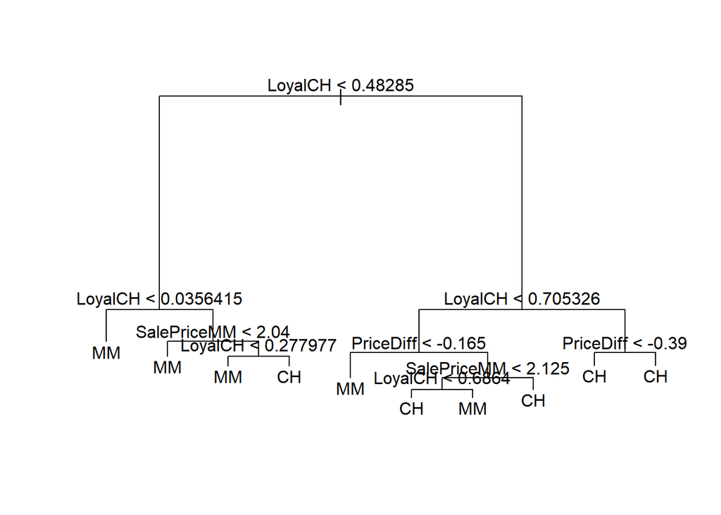

```r
plot(model)
text(model,pretty = 0)
```

Use the Test Data and Create a Confusion Matrix:

Using the test data to make a prediction yields a test error rate of 16.9%. This is slightly higher than the training error rate, which is generally expected. There were 36 misclassifications and 177 valid classifications.

```r
prediction<-predict(model,test,type = 'class')
table(prediction, test$Purchase)
```

```
##
## prediction  CH  MM
##         CH 120  26
##         MM  10  57
```

```r
cat("Test Error Rate:",toString((26+10)/length(test$Purchase)))
```

```
## Test Error Rate: 0.169014084507042
```

Use Cross Validation to Find Optimal Tree Size:

To cross validate the tree model, the cv.tree function is used. Setting FUN to prune.misclass ensures that the training error rate is used as the criteria for model improvement. Displaying the results of the model shows the deviation at each number of terminal nodes.

```r
cvModel<-cv.tree(model, FUN = prune.misclass)
cvModel
```

```
## $size
## [1] 10  9  7  4  2  1
##
## $dev
## [1] 166 163 162 161 184 334
##
## $k
## [1]       -Inf   0.000000   2.500000   4.666667   9.000000 161.000000
##
## $method
## [1] "misclass"
##
## attr(,"class")
## [1] "prune"         "tree.sequence"
```

Plot the CV Results:

Plotting the cross validation results shows that using 4 terminal nodes yields the smallest deviation/error rate for the model. This differs from our original model that used 10 terminal nodes. Not only is the error rate lower, less nodes and branches means there is a lower chance of overfitting.

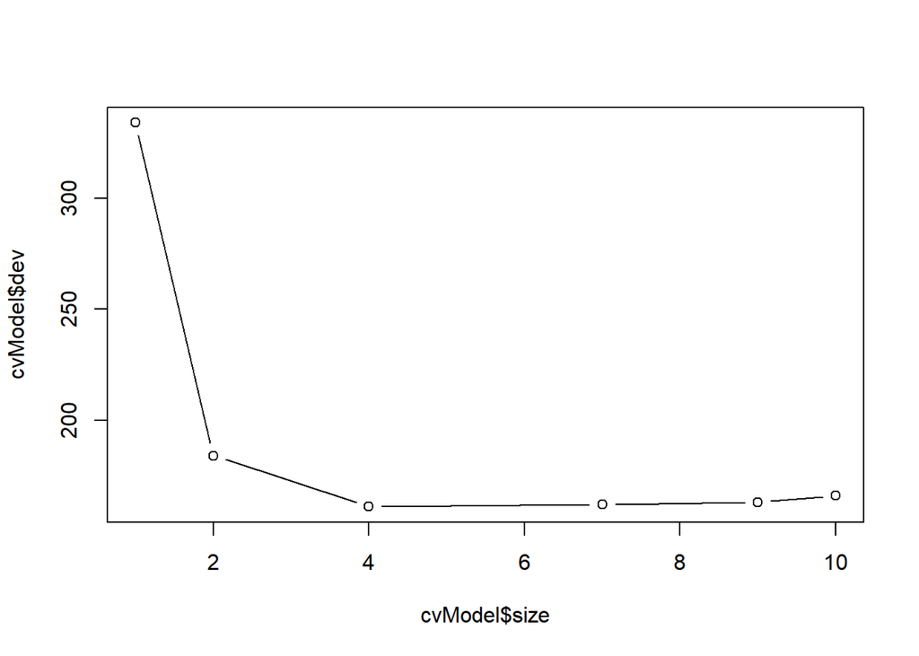

```r
plot(cvModel$size,cvModel$dev, type = 'b')
```

Make a Model Using the Best Pruned Tree:

Using the number of terminal nodes found above, a pruned model is created using the prune.misclass function. The plot shows the branches for a 4 terminal node model.

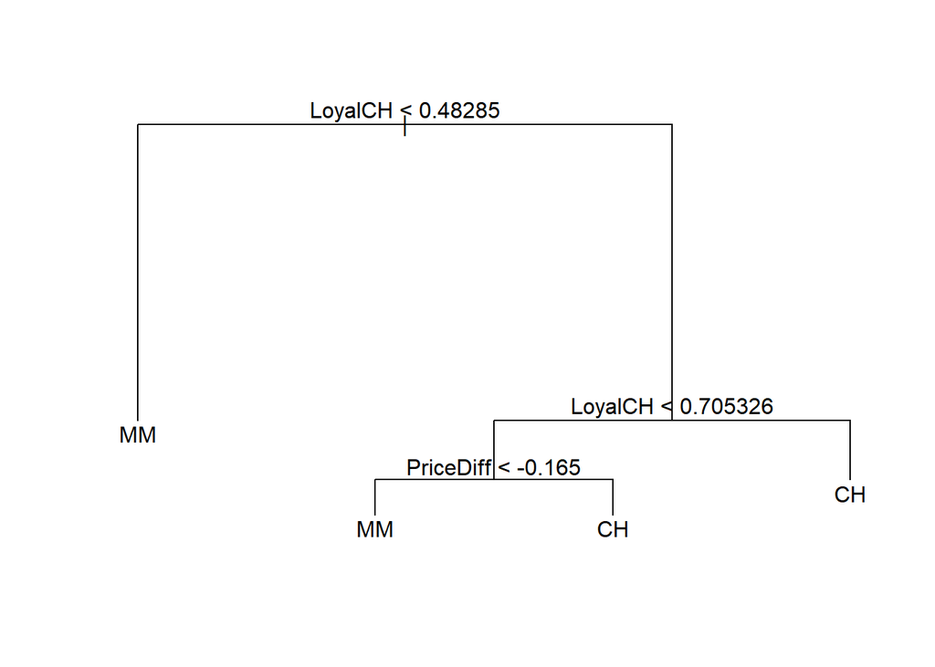

```r
pruneModel<-prune.misclass(model,best=4)
plot(pruneModel)
text(pruneModel,pretty=0)
```

Find the New Test Error Rate:

Using the pruned model yields different results from the original model. The training error rate was slightly higher at 18.09% as opposed to the original 15.87%. The test error rate fell by 2.82% from the original test error rate of 16.9% to the pruned test error rate of 14.08%.

```r
summary(pruneModel)
```

```
##
## Classification tree:
## snip.tree(tree = model, nodes = c(7L, 13L, 2L))
## Variables actually used in tree construction:
## [1] "LoyalCH"   "PriceDiff"
## Number of terminal nodes:  4
## Residual mean deviance:  0.8888 = 758.2 / 853
## Misclassification error rate: 0.1809 = 155 / 857
```

```r
prunePred<-predict(pruneModel,test,type = 'class')
table(prunePred, test$Purchase)
```

```
##
## prunePred  CH  MM
##        CH 117  17
##        MM  13  66
```

```r
cat("Test Error Rate:",toString((13+17)/length(test$Purchase)))
```

```
## Test Error Rate: 0.140845070422535
```

## Bagging and Random Forest

Author: Itty Bitty Witty

### Summary/description:

Bagging, random forests and boosting use trees as building blocks to construct more powerful prediction models.

Bagging, also known as bootstrap aggregation, is a general purpose procedure for reducing the variance of a statistical learning model, usually decision trees. Some decision trees, notably in Section 8.1 of the book, suffer from high variance. Bagging helps reduce that variance.

In bagging, we generate B different bootstrapped training data sets and train our method on the bth training set to get $\hat{f}^{*b} (x)$, and average the predictions. The full formula looks like this:

$\hat{f}_{bag} (x)$=$\frac{1}{B}$ $\sum_{b=1}^{B} \hat{f}^{*b} (x)$

Bagging can be used for regression models, but it is most useful with decision trees.

Something to note - the number of trees $B$ is not a critical parameter with bagging; using a large $B$ will not lead to overfitting.

### When to employ this method/model:

** For quantitative variables ** : Do above

** For qualitative variables ** : Simplest approach is to record the class predicted by each of the B trees, and take a majority vote: the most common occurring class among B predictions.